# fs_oc_predict(): Verification and Methods Note

- Show All Code
- Hide All Code
- View Source

Predicted operating characteristics of the maxeffCons search over a population-enumerated candidate family, scored against the n = 500 and n = 700 MD40 runs

Author

Larry F. León

Published

August 29, 2026

```r
# This document reads precomputed objects and the tracked payloads.  It
# computes nothing heavy and types no number: every figure in prose is inline R.
# Re-pointed (cc_task_oc_verification_repoint_2026-08-31) at the corrected
# 13-confounder object, whose $alt and $null mirror the fields of the two
# superseded 08-29 objects; the shared settings (fs_args, seed, draws) sit at
# its top level and are copied onto the two aliases the chunks below use.
.dev <- file.path("..", "..", "..", "..", "dev", "glm-continuous-sims")
.grid_path <- file.path(.dev, "oc_wrapper_grid_corrected_2026-08-30.rds")
stopifnot(file.exists(.grid_path))
C <- readRDS(.grid_path)
stopifnot(identical(unname(C$superseded[["alt"]]), "dev/glm-continuous-sims/oc_wrapper_grid_2026-08-29.rds"))
G <- C$alt; G$fs_args <- C$fs_args; G$seed <- C$seed; G$draws <- C$draws
stopifnot(all(c("n500_resample", "n500_split", "n700_resample", "n700_split") %in% names(G$runs)))
.pay <- lapply(G$payloads, function(p) readRDS(file.path("..", "..", "..", "..", p)))
names(.pay) <- names(G$payloads)
stopifnot(inherits(.pay[["500"]]$scale, "fs_dgm_scale"))
.reg <- G$scale$regions
.iQ <- match("Q", .reg$region); .iQc <- match("Qc", .reg$region)
piQ     <- .reg$P_g[.iQ]
tauQc   <- abs(.reg$m_tau[.iQc])
bint    <- abs(.reg$m_tau[.iQ]) - tauQc
seQ1000 <- sqrt(.reg$V_eff[.iQ] / (1000 * piQ))
c1 <- G$fs_args$effect.threshold; c2 <- G$fs_args$consistency.threshold
pcons <- G$fs_args$pconsistency.threshold
z_p <- qnorm((1 + pcons) / 2)
.f  <- function(x, d = 3) formatC(x, format = "f", digits = d)
.fm <- function(x) formatC(x, format = "d", big.mark = ",")
```

# 1 What the wrapper computes

`fs_oc_predict()` predicts the operating characteristics of the maxeffCons search from the joint normal law of the candidates’ fitted effects. It consumes a **candidate family** through a nine-field interface – the label `lab`, prevalence `Pg`, purity `PQg`, mean `beta_g`, standard error `se_g`, classification vectors `sens_g` and `spec_g`, the overlap matrix `ovl`, and the count `M` (plus `P(Q)`, carried explicitly for the NPV) – and returns declaration rates, the selection distribution and the selection-weighted functionals. Everything above the interface is **family-agnostic**: the draw model, the two gates, the argmax and the functionals do not look at how the family was built. The family in this document is the population enumeration of §2; a hand-built or stylized family (the analytic document’s M = 16) goes through the same code, which is how the wrapper was gated for fidelity (bit-identical to the `worked-predictions` chunk at its own seed).

The family throughout is the **corrected 13-confounder enumeration** — the driver’s `confounders.name`, `str2` included — read from `oc_wrapper_grid_corrected_2026-08-30.rds`: M = 1,696 at n = 500, M = 1,890 at n = 700 and M = 1,696 at the null. (The 08-29 build of this document read the 12-variable enumeration without `str2` — M = 1601 / 1784 / 1601; against it every functional moved by ≤ 0.1 and every inverted `c1` by < 0.25, so the conclusions below are unchanged and the numbers are not.)

# 2 The family

`fs_oc_family_enumerate()` builds the family the search ranks over as a **population enumeration under the `forestsearch()` cut specification**, on the DGM’s super-population frame (`df_super`, 5,000 rows) rather than on a sampled trial:

1. **Cuts** from the package’s own `get_FSdata()`: `conf.cont_jcuts` (`age = 10`, `preanti = 10`) places J cuts at the k/(J+1) **population** quantiles; the remaining continuous variables take the `cut_type = "default"` set (q25 / median / q75); binary factors enter as themselves; `collapse_cuts` merges coincident cuts. 37 cut expressions result.
2. **Both directions** of every cut, as the search’s `dummy()` expansion does: 74 indicator columns.
3. **Combinations** to `maxk = 2` with the search’s own combination helpers: 2,775.
4. **Structural floors only**, on the population frame and in the search’s order: empty pairwise intersections (the search’s status 0); `minp` per constituent factor; the `rmin` redundancy rule, read at trial size `n` as “each added factor removes more than `rmin`/`n` of the population”; and the size floor `Pg >= n.min/n`.
5. Candidates with **identical population membership** collapse to one.

Deliberately **excluded**: the GRF variable-importance pre-screen, the effect screen, the consistency screen and the statistics-keyed near-duplicate removal. The first is a sample-fitted ranking with no population counterpart; the second and third *are* the gate the wrapper evaluates; the fourth keys on sample statistics of candidates that have already passed the gate. Including any of them would put sample-realized screening into an object meant to be a fixed population law.

```r
.fam_row <- function(n) {
  f <- G$families[[as.character(n)]]; k <- f$counts
  data.frame(n = n, `cut columns` = k[["cut_columns"]], enumerated = k[["enumerated"]],
             empty = k[["empty"]], minp = k[["minp"]], rmin = k[["rmin"]],
             `size (Pg < n.min/n)` = k[["size"]], kept = k[["kept"]],
             duplicate = k[["duplicate"]], M = k[["M"]],
             `floor n.min/n` = round(f$floor_Pg, 4), check.names = FALSE)
}
knitr::kable(rbind(.fam_row(500), .fam_row(700)), row.names = FALSE,
  caption = "The population enumeration at each stage, for the two trial sizes. The only input that changes with n is the size floor n.min/n.")
```

The population enumeration at each stage, for the two trial sizes. The only input that changes with n is the size floor n.min/n.

| n | cut columns | enumerated | empty | minp | rmin | size (Pg < n.min/n) | kept | duplicate | M | floor n.min/n |
| --- | --- | --- | --- | --- | --- | --- | --- | --- | --- | --- |
| 500 | 74 | 2775 | 127 | 0 | 107 | 656 | 1885 | 189 | 1696 | 0.1200 |
| 700 | 74 | 2775 | 127 | 0 | 102 | 448 | 2098 | 208 | 1890 | 0.0857 |

The realized family is M = 1,696 at n = 500 and M = 1,890 at n = 700 – two orders of magnitude above the analytic document’s stylized 16, which is the reason the wrapper carries a size guard before any M-by-M allocation.

# 3 Means and standard errors

Every mean and scale comes from `fs_dgm_scale(dgm)`, the computed finite-population sampling scale of the difference-in-means estimator, read from the fixture (and identical to the `$scale` object both payloads carry). With `Q` the true harm region, `P(Q)` = 0.3446, `tauQc` = |m_tau[Qc]| = 26.255 and the planted interaction `bint` = |m_tau[Q]| − |m_tau[Qc]| = 13.745:

- **Mixture identity.** A candidate `g` with purity `PQg = P(g ∩ Q)/P(g)` has oriented mean `beta_g = tauQc + bint · PQg`, because the effect is constant on `Q` and on `Qc` and `g` mixes the two in proportion `PQg`.
- **Prevalence-scaled anchor SE.** `seQ1000` = sqrt(V_eff[Q] / (1000 · P(Q))) = 13.9909 is the estimator SD on `Q` at n = 1000; a candidate of prevalence `Pg` at trial size `n` has `se_g = seQ1000 · sqrt(1000/n) · sqrt(P(Q)/Pg)`.

**Caveat.** `fs_dgm_scale()` is exact for identity-scale measures only (MD, RD, IRD); this document is MD. The SE identity treats the region size and arm split as fixed at their expectations and uses `V_eff[Q]` for every candidate, so a mixed candidate’s within-arm variance inflation from the mixture is not carried in `se_g`. The `sigma_D` diagnostic of §5 is what checks that this approximation is adequate at the gate.

# 4 The covariance

Candidates overlap, so their fitted effects are correlated. With `ovl` the M-by-M matrix of `P(g_i ∩ g_j)`,

$$\rho_{ij} = \frac{P(g_i \cap g_j)}{\sqrt{P(g_i)\,P(g_j)}}, \qquad
S_g = \rho \circ (se_g\, se_g^{\top}),$$

the correlation of two difference-in-means estimators sharing the overlap’s subjects. `S_g` is exactly rank-deficient by construction: for every cut, the two directions’ effects combine linearly into the full-sample effect. Draws are generated through `fs_sym_root()`, the **symmetric** root $V D^{1/2} V^{\top}$ with eigenvalues clamped at zero – not $V D^{1/2}$ – because the eigenvector basis is not a continuous function of the matrix inside a degenerate subspace, and a pinned seed cannot fix the basis the draws are multiplied by. The symmetric root is basis-free, so the draws are a continuous and reproducible function of the inputs.

# 5 The two gates

The package’s consistency stage represents the random 50/50 split’s two half-sample effects as $\hat\beta \pm D$, with $D = \sum_i G_i\, \mathrm{dfbeta}_i$ for mean-zero unit-variance multipliers $G_i$ (Rademacher = the 50/50 split) and $\sigma_D = \sqrt{\sum_i \mathrm{dfbeta}_i^2}$, the sandwich SE of the subgroup treatment coefficient. A split is consistent iff both halves clear `c2`, i.e. $|D| \le \hat\beta - c_2$, so the consistency rate is

$$P(|D| \le \hat\beta - c_2) = 2\,\Phi\!\left(\frac{\hat\beta - c_2}{\sigma_D}\right) - 1 .$$

**Production** (`consistency_method = "resample"`, the package default) thresholds this probability at `pconsistency` = 0.9; the search drops a candidate when `p.consistency < pconsistency.threshold`. Inverting,

$$2\Phi\!\left(\tfrac{\hat\beta - c_2}{\sigma_D}\right) - 1 \ge p
\iff \hat\beta \ge c_2 + z_p\,\sigma_D, \qquad z_p = \Phi^{-1}\!\big(\tfrac{1+p}{2}\big) = 1.6449,$$

combined with the effect screen $\hat\beta \ge c_1$. The **analytic document’s historical gate** (`"split"`) instead realizes one `D`: it draws one half-sample pair `W1`, `W2` (each with covariance `2·S_g`) and declares when `(W1 + W2 >= 2·c1) & (W1 >= c2) & (W2 >= c2)`.

**The `sigma_D = se_g` identification.** In the draw model, `Bhat = (W1 + W2)/2` has covariance `S_g` and `D = (W1 − W2)/2` has covariance `S_g` as well, so the natural stand-in for `sigma_D` is `se_g`. This was checked from source and on data rather than taken on trust (`dev/glm-continuous-sims/sigma_d_diagnostic_2026-08-29.R`, one simulated MD40 trial at n = 500, ten candidates spanning prevalence 0.12–0.92): `sigma_D` equals the direct dfbeta sum of squares to 1e-10, sits within 4% of the classical model SE and within 7% of the population `se_g`, with no trend in prevalence (Spearman −0.07 and −0.12). No constant factor is carried. Under this identification the production gate is a single threshold on the full-sample draw, `(Bhat >= c1) & (Bhat − c2 >= z_p · se_g)`, and only `Bhat ~ N(beta_g, S_g)` is drawn.

So: **`"resample"` is the production screen; `"split"` is the document’s historical one.** Both are reported below.

# 6 Selection and the functionals

Family declaration is any candidate declaring (`det`, rate `det_rate`). The selected rule is the effect maximiser among declaring candidates – the maxeffCons argmax of `Bhat` with non-declaring entries masked to −∞. With `p_sel[m]` the unconditional selection probability and `sel_c = p_sel / det_rate` the selection distribution given declaration:

| quantity | formula |
| --- | --- |
| `det_rate` | `mean(det)` |
| `EnH` | `n · Σ sel_c · Pg` – expected selected-subgroup size in subjects |
| `Esens`, `Espec` | `Σ sel_c · sens_g`, `Σ sel_c · spec_g` |
| `Eppv` | `Σ sel_c · PQg` |
| `Enpv` | `Σ sel_c · (1 − Pg − (P(Q) − PQg·Pg)) / (1 − Pg)` |
| `EbetaH` | `Σ sel_c · beta_g` – oriented true effect on the selected rule |
| `Enaive_bias` | mean over declaring draws of `Bhat[winner] − beta_g[winner]` |
| `mass_below` | `Σ sel_c[beta_g < c1]` |

All are selection-weighted **population** functionals conditional on declaration. Monte-Carlo SEs are `sqrt(p(1−p)/draws)` for the proportions.

# 7 The tables

```r
.rows <- c("det_rate", "EnH", "Esens", "Espec", "Eppv", "Enpv", "EbetaH", "Enaive_bias")
.lab  <- c("detection rate", "E|Hhat| given detection", "E[sens]", "E[spec]",
           "E[PPV]", "E[NPV]", "E[beta(Hhat)] oriented", "naive bias vs beta(Hhat)")
.cell <- function(v, se, d = 3) {
  ifelse(is.na(v), "—", ifelse(is.na(se) | se == 0, .f(v, d),
                               paste0(.f(v, d), " (", .f(se, 4), ")")))
}
.table_n <- function(n) {
  r  <- G$runs[[sprintf("n%d_resample", n)]]$pred
  s  <- G$runs[[sprintf("n%d_split", n)]]$pred
  m  <- G$measured[[as.character(n)]]
  a_r <- unlist(r[.rows]); a_s <- unlist(s[.rows]); a_m <- unlist(m[.rows])
  se_r <- c(r$det_rate_se, rep(NA, 7)); se_s <- c(s$det_rate_se, rep(NA, 7))
  se_m <- unlist(m[paste0(.rows, "_se")])
  d <- c(3, 1, 3, 3, 3, 3, 2, 2)
  out <- data.frame(
    quantity = c(.lab, "M"),
    `analytic "resample"` = c(mapply(.cell, a_r, se_r, d), .fm(r$M)),
    `analytic "split"`    = c(mapply(.cell, a_s, se_s, d), .fm(s$M)),
    simulation            = c(mapply(.cell, a_m, se_m, d), "—"),
    check.names = FALSE)
  knitr::kable(out, row.names = FALSE, caption = sprintf(
    "n = %d: analytic predictions under the two gates (M = %s, %s draws, seed %d) against the measured run (%d replicates; MC SE in parentheses where it exists on both sides).",
    n, .fm(r$M), .fm(G$draws), G$seed, m$n_sims))
}
.table_n(500)
```

n = 500: analytic predictions under the two gates (M = 1,696, 200,000 draws, seed 20260825) against the measured run (1000 replicates; MC SE in parentheses where it exists on both sides).

| quantity | analytic “resample” | analytic “split” | simulation |
| --- | --- | --- | --- |
| detection rate | 0.999 (0.0001) | 1.000 | 1.000 |
| E\|Hhat\| given detection | 70.8 | 70.8 | 72.3 (0.4148) |
| E[sens] | 0.164 | 0.164 | 0.171 (0.0035) |
| E[spec] | 0.870 | 0.870 | 0.869 (0.0019) |
| E[PPV] | 0.400 | 0.399 | 0.405 (0.0080) |
| E[NPV] | 0.664 | 0.664 | 0.665 (0.0016) |
| E[beta(Hhat)] oriented | 31.75 | 31.74 | 31.76 (0.1084) |
| naive bias vs beta(Hhat) | 75.53 | 75.38 | 74.27 (0.5771) |
| M | 1,696 | 1,696 | — |

```r
.table_n(700)
```

n = 700: analytic predictions under the two gates (M = 1,890, 200,000 draws, seed 20260825) against the measured run (1000 replicates; MC SE in parentheses where it exists on both sides).

| quantity | analytic “resample” | analytic “split” | simulation |
| --- | --- | --- | --- |
| detection rate | 1.000 (0.0000) | 1.000 | 0.999 (0.0010) |
| E\|Hhat\| given detection | 73.0 | 73.1 | 73.6 (0.4215) |
| E[sens] | 0.122 | 0.122 | 0.123 (0.0028) |
| E[spec] | 0.905 | 0.905 | 0.904 (0.0015) |
| E[PPV] | 0.403 | 0.404 | 0.402 (0.0087) |
| E[NPV] | 0.662 | 0.662 | 0.662 (0.0012) |
| E[beta(Hhat)] oriented | 31.80 | 31.81 | 31.76 (0.1172) |
| naive bias vs beta(Hhat) | 75.57 | 75.49 | 77.09 (0.5639) |
| M | 1,890 | 1,890 | — |

```r
.tim <- do.call(rbind, lapply(G$runs, function(u)
  data.frame(n = u$n, gate = u$gate, M = u$pred$M, seconds = round(u$secs),
             `peak MB` = round(u$peak_MB), check.names = FALSE)))
knitr::kable(.tim, row.names = FALSE,
  caption = "Wall-clock and peak memory per evaluation. The resample branch draws one matrix; the split branch draws two.")
```

Wall-clock and peak memory per evaluation. The resample branch draws one matrix; the split branch draws two.

| n | gate | M | seconds | peak MB |
| --- | --- | --- | --- | --- |
| 500 | resample | 1696 | 408 | 12018 |
| 500 | split | 1696 | 785 | 17914 |
| 700 | resample | 1890 | 503 | 13370 |
| 700 | split | 1890 | 973 | 17027 |

# 8 Threshold sweeps and the inversion

```r
stopifnot(!is.null(G$sweep), !is.null(G$invert))
.sw <- G$sweep$table; .iv <- G$invert$table
.c1_fix <- G$fs_args$effect.threshold
.n_c1 <- length(G$sweep$c1)
```

The design point is that at fixed `n` the family, `Pg`, `beta_g`, `se_g` and `S_g` are fixed, and **both gates are thresholds on draws that do not depend on `c1` or `c2`** – `(Bhat >= c1) & (Bhat - c2 >= z_p·se_g)` and `(W1 + W2 >= 2·c1) & (W1 >= c2) & (W2 >= c2)`. So `fs_oc_grid()` draws **once per `n` and gate** and sweeps the thresholds against that draw set: the 21 values of `c1` below cost arithmetic, not draws. Only `n` forces re-enumeration and re-drawing, because the size floor is `n.min/n`. The sweep’s point at the driver’s `c1` = 30 is `identical()` to the single-point `fs_oc_predict()` evaluation of §7 (asserted in the precompute), and one draw set was held whole (`block = Inf`), the exact path.

```r
.st <- G$sweep_timing
knitr::kable(data.frame(n = .st$n, gate = .st$consistency_method, M = .st$M,
                        `enumerate (s)` = round(.st$enumerate_secs, 1),
                        `draw (s)` = round(.st$draw_secs),
                        `sweep (s)` = round(.st$sweep_secs),
                        `per c1 (s)` = round(.st$sweep_secs / .n_c1, 1),
                        check.names = FALSE), row.names = FALSE,
  caption = sprintf("Wall-clock split for the sweep over %d values of c1 at c2 = %g: enumeration and drawing once per (n, gate), then the sweep.", .n_c1, G$sweep$c2))
```

Wall-clock split for the sweep over 21 values of c1 at c2 = 10: enumeration and drawing once per (n, gate), then the sweep.

| n | gate | M | enumerate (s) | draw (s) | sweep (s) | per c1 (s) |
| --- | --- | --- | --- | --- | --- | --- |
| 500 | resample | 1696 | 0 | 381 | 77 | 3.6 |
| 500 | split | 1696 | 0 | 766 | 74 | 3.5 |
| 700 | resample | 1890 | 0 | 475 | 86 | 4.1 |
| 700 | split | 1890 | 0 | 945 | 82 | 3.9 |

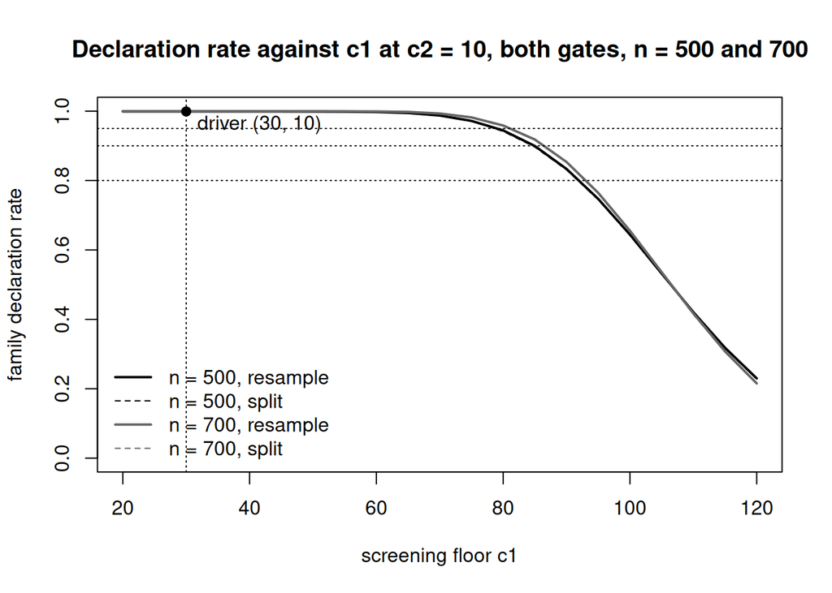

```r
plot(NA, xlim = range(G$sweep$c1), ylim = c(0, 1),
     xlab = "screening floor c1", ylab = "family declaration rate",
     main = sprintf("Declaration rate against c1 at c2 = %g, both gates, n = 500 and 700", G$sweep$c2))
.sty <- list(`500` = list(col = "black"), `700` = list(col = "grey40"))
for (n in c(500, 700)) for (g in c("resample", "split")) {
  r <- .sw[.sw$n == n & .sw$consistency_method == g, ]
  r <- r[order(r$c1), ]
  lines(r$c1, r$det_rate, col = .sty[[as.character(n)]]$col,
        lty = if (g == "resample") 1 else 2, lwd = if (g == "resample") 2 else 1)
}
abline(h = G$invert$targets, lty = 3)
abline(v = .c1_fix, lty = 3)
.r0 <- .sw[.sw$c1 == .c1_fix & .sw$n == 500 & .sw$consistency_method == "resample", ]
points(.c1_fix, .r0$det_rate, pch = 19); text(.c1_fix, .r0$det_rate, "  driver (30, 10)", adj = c(0, 1.3))
legend("bottomleft", bty = "n",
       legend = c("n = 500, resample", "n = 500, split", "n = 700, resample", "n = 700, split"),
       col = c("black", "black", "grey40", "grey40"), lty = c(1, 2, 1, 2), lwd = c(2, 1, 2, 1))
```

```r
.ivt <- .iv[order(.iv$n, .iv$consistency_method, .iv$target), ]
knitr::kable(data.frame(
  n = .ivt$n, gate = .ivt$consistency_method, target = .ivt$target,
  `c1 (inverted)` = ifelse(.ivt$attainable, .f(.ivt$value, 2), "NA"),
  `achieved rate` = ifelse(.ivt$attainable,
                           paste0(.f(.ivt$achieved, 4), " (", .f(.ivt$achieved_se, 4), ")"),
                           paste0("infeasible (ceiling ", .f(.ivt$ceiling, 4), ")")),
  `next step` = ifelse(.ivt$attainable, .f(.ivt$next_step_rate, 4), "—"),
  check.names = FALSE), row.names = FALSE,
  caption = sprintf("fs_oc_invert(): the c1 at which the family declaration rate meets each target, at c2 = %g, per n and gate (%s draws, seed %d). The achieved rate is the step the target falls on, with its MC SE; the next-step rate is the first value below the target.",
                    G$sweep$c2, .fm(G$draws), G$seed))
```

fs_oc_invert(): the c1 at which the family declaration rate meets each target, at c2 = 10, per n and gate (200,000 draws, seed 20260825). The achieved rate is the step the target falls on, with its MC SE; the next-step rate is the first value below the target.

| n | gate | target | c1 (inverted) | achieved rate | next step |
| --- | --- | --- | --- | --- | --- |
| 500 | resample | 0.80 | 92.04 | 0.8000 (0.0009) | 0.8000 |
| 500 | resample | 0.90 | 84.95 | 0.9000 (0.0007) | 0.9000 |
| 500 | resample | 0.95 | 79.14 | 0.9500 (0.0005) | 0.9500 |
| 500 | split | 0.80 | 91.90 | 0.8000 (0.0009) | 0.8000 |
| 500 | split | 0.90 | 84.68 | 0.9000 (0.0007) | 0.9000 |
| 500 | split | 0.95 | 78.81 | 0.9500 (0.0005) | 0.9500 |
| 700 | resample | 0.80 | 93.19 | 0.8000 (0.0009) | 0.8000 |
| 700 | resample | 0.90 | 86.64 | 0.9000 (0.0007) | 0.9000 |
| 700 | resample | 0.95 | 81.28 | 0.9500 (0.0005) | 0.9500 |
| 700 | split | 0.80 | 93.10 | 0.8000 (0.0009) | 0.8000 |
| 700 | split | 0.90 | 86.60 | 0.9000 (0.0007) | 0.9000 |
| 700 | split | 0.95 | 81.29 | 0.9500 (0.0005) | 0.9500 |

```r
.sat <- .sw[.sw$c1 <= 60, ]
.c1_drop <- vapply(split(.sw, list(.sw$n, .sw$consistency_method)), function(r) {
  r <- r[order(r$c1), ]; r$c1[which(r$det_rate < 0.95)[1]] }, numeric(1))
```

This is the design calculation the wrapper now supports at family level: the `c1` that gives a target declaration rate – “80% power” under this alternative, and the same number read as a type-I error under a null DGM – found on fixed draws by bracketing and bisection, with the attainability ceiling reported when the other threshold binds. Under the alternative at this fixture the rate saturates: every curve is above 0.95 until `c1` reaches 80–85, so the interesting range of `c1` lies well above the driver’s 30, and the inverted values in the table are where the declaration rate actually begins to move.

# 9 The null cell

```r
# The null cell of the corrected object (mirrors the superseded oc_wrapper_null_2026-08-29.rds).
stopifnot(identical(unname(C$superseded[["null"]]), "dev/glm-continuous-sims/oc_wrapper_null_2026-08-29.rds"))
N0 <- C$null; N0$fs_args <- C$fs_args; N0$draws <- C$draws; N0$seed <- C$seed
.nr <- N0$runs$resample$pred; .ns <- N0$runs$split$pred; .nm <- N0$measured
.nsw <- N0$sweep$table; .niv <- N0$invert$table
```

The null DGM (`generate_glm_dgm(model = "null")`: the same ACTG175 frame, factors and cut specification, `beta_inter = 0`, so Q is empty and every subject has the same treatment effect) is the one cell where the two gates can differ – under the alternative both saturate – and the one cell the analytic document could only address with its stylised M = 16 family. `fs_oc_family_enumerate()` detects the null structurally: `df_super$flag_harm` has no member, the fact the null driver itself asserts (`sum(inQ) == 0L`, `is.na(effect_Q)`, `beta_inter == 0`), cross-checked against `dgm$model`. `fs_dgm_scale()`’s default regions need a non-empty Q; its public `regions` argument computes the same columns on the whole population, which is what the null branch uses. The family’s fields become:

| field | null value | note |
| --- | --- | --- |
| `beta_g` | 26.255 for every g | the common effect, |
| `se_g` | `sqrt(V_eff[S] / (1000 · 1)) · sqrt(1000/n) · sqrt(1/Pg)` | the whole-population effective variance (`V_eff[S]` = 67940.1; the alternative’s three regions spread 0.86%) at `(n, Pg)`, the same prevalence scaling |
| `PQg` | 0 | `P(g ∩ Q) = 0` |
| `sens_g` | `NA` | 0/0 – undefined, not zero; `E[sens]` is `NA` downstream and nothing else is touched |
| `spec_g` | `1 − Pg` | `Qc` is the whole population |
| NPV | 1 | follows from `P(Q) = 0` |

Enumeration, floors, overlaps and the covariance are unchanged: the null family has M = 1,696 at n = 500, against the alternative’s 1,696: the null DGM samples the same super-population frame under the same seed and only zeroes the harm flag, so the cut space and the candidate set are the same objects.

```r
.nrows <- c("det_rate", "EnH", "Esens", "Espec", "Eppv", "Enpv", "EbetaH", "Enaive_bias", "mass_below")
.nlab  <- c("false declaration rate", "E|Hhat| given declaration", "E[sens]", "E[spec]",
            "E[PPV]", "E[NPV]", "E[beta(Hhat)] oriented", "naive bias vs beta(Hhat)",
            "selection mass on rules with mean < c1")
.ncell <- function(v, se, d) ifelse(is.na(v), "NA (0/0)", ifelse(is.na(se) | se == 0, .f(v, d),
                                    paste0(.f(v, d), " (", .f(se, 4), ")")))
.d <- c(4, 1, 3, 3, 3, 3, 3, 2, 3)
.m_se <- c(.nm$det_rate_se, .nm$EnH_se, NA, .nm$Espec_se, NA, NA, .nm$EbetaH_se, .nm$Enaive_bias_se, NA)
.m_v  <- c(.nm$det_rate, .nm$EnH, .nm$Esens, .nm$Espec, .nm$Eppv, .nm$Enpv, .nm$EbetaH, .nm$Enaive_bias, NA)
knitr::kable(data.frame(
  quantity = c(.nlab, "per-candidate rate range (min .. max P1)", "implied L_eff", "M"),
  `analytic "resample"` = c(mapply(.ncell, unlist(.nr[.nrows]), c(.nr$det_rate_se, rep(NA, 8)), .d),
                            sprintf("%s .. %s", .f(N0$runs$resample$p1_range[1], 4), .f(N0$runs$resample$p1_range[2], 4)),
                            .f(N0$runs$resample$L_eff, 1), .fm(.nr$M)),
  `analytic "split"`    = c(mapply(.ncell, unlist(.ns[.nrows]), c(.ns$det_rate_se, rep(NA, 8)), .d),
                            sprintf("%s .. %s", .f(N0$runs$split$p1_range[1], 4), .f(N0$runs$split$p1_range[2], 4)),
                            .f(N0$runs$split$L_eff, 1), .fm(.ns$M)),
  simulation = c(mapply(.ncell, .m_v, .m_se, .d), "—", "—", "—"),
  check.names = FALSE), row.names = FALSE,
  caption = sprintf("The null cell at n = %d, c1 = %g, c2 = %g: analytic false-declaration and selection functionals under the two gates (%s draws, seed %d) against the measured null run (%d replicates, %d declaring). L_eff = log(1 − fam) / log(1 − max P1), the analytic document's definition.",
                    N0$n, N0$fs_args$effect.threshold, N0$fs_args$consistency.threshold, .fm(N0$draws), N0$seed, .nm$n_sims, .nm$n_used))
```

The null cell at n = 500, c1 = 30, c2 = 10: analytic false-declaration and selection functionals under the two gates (200,000 draws, seed 20260825) against the measured null run (1000 replicates, 998 declaring). L_eff = log(1 − fam) / log(1 − max P1), the analytic document’s definition.

| quantity | analytic “resample” | analytic “split” | simulation |
| --- | --- | --- | --- |
| false declaration rate | 0.9969 (0.0001) | 1.0000 (0.0000) | 0.9980 (0.0014) |
| E\|Hhat\| given declaration | 70.9 | 70.8 | 72.0 (0.4039) |
| E[sens] | NA (0/0) | NA (0/0) | NA (0/0) |
| E[spec] | 0.858 | 0.858 | 0.856 (0.0008) |
| E[PPV] | 0.000 | 0.000 | 0.000 |
| E[NPV] | 1.000 | 1.000 | 1.000 |
| E[beta(Hhat)] oriented | 26.255 | 26.255 | 26.255 (0.0000) |
| naive bias vs beta(Hhat) | 76.32 | 76.07 | 74.85 (0.5668) |
| selection mass on rules with mean < c1 | 1.000 | 1.000 | NA (0/0) |
| per-candidate rate range (min .. max P1) | 0.1215 .. 0.3781 | 0.3457 .. 0.3774 | — |
| implied L_eff | 12.2 | 25.8 | — |
| M | 1,696 | 1,696 | — |

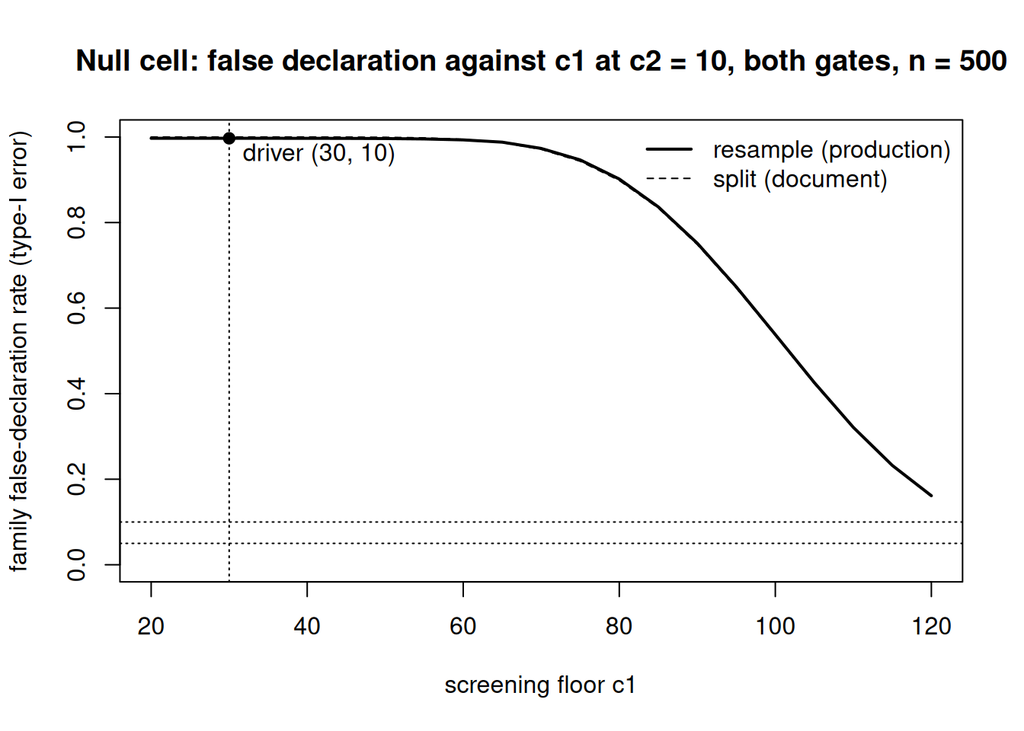

```r
plot(NA, xlim = range(N0$sweep$c1), ylim = c(0, 1),
     xlab = "screening floor c1", ylab = "family false-declaration rate (type-I error)",
     main = sprintf("Null cell: false declaration against c1 at c2 = %g, both gates, n = %d", N0$sweep$c2, N0$n))
for (g in c("resample", "split")) {
  r <- .nsw[.nsw$consistency_method == g, ]; r <- r[order(r$c1), ]
  lines(r$c1, r$det_rate, lty = if (g == "resample") 1 else 2, lwd = if (g == "resample") 2 else 1)
}
abline(h = c(0.05, 0.10), lty = 3); abline(v = N0$fs_args$effect.threshold, lty = 3)
points(N0$fs_args$effect.threshold, .nr$det_rate, pch = 19)
text(N0$fs_args$effect.threshold, .nr$det_rate, "  driver (30, 10)", adj = c(0, 1.3))
legend("topright", bty = "n", legend = c("resample (production)", "split (document)"),
       lty = c(1, 2), lwd = c(2, 1))
```

```r
.nivt <- .niv[order(.niv$consistency_method, .niv$target), ]
knitr::kable(data.frame(
  gate = .nivt$consistency_method, `target type-I error` = .nivt$target,
  `c1 (inverted)` = ifelse(.nivt$attainable, .f(.nivt$value, 2), "NA"),
  `achieved rate` = ifelse(.nivt$attainable, paste0(.f(.nivt$achieved, 4), " (", .f(.nivt$achieved_se, 4), ")"),
                           paste0("infeasible (ceiling ", .f(.nivt$ceiling, 4), ")")),
  check.names = FALSE), row.names = FALSE,
  caption = sprintf("Null cell: the c1 at which the false-declaration rate equals each target at c2 = %g, per gate, by the order-statistic reduction on one draw set per gate.", N0$sweep$c2))
```

Null cell: the c1 at which the false-declaration rate equals each target at c2 = 10, per gate, by the order-statistic reduction on one draw set per gate.

| gate | target type-I error | c1 (inverted) | achieved rate |
| --- | --- | --- | --- |
| resample | 0.05 | 133.23 | 0.0500 (0.0005) |
| resample | 0.10 | 125.70 | 0.1000 (0.0007) |
| resample | 0.20 | 117.11 | 0.2000 (0.0009) |
| resample | 0.50 | 101.64 | 0.5000 (0.0011) |
| resample | 0.80 | 87.29 | 0.8000 (0.0009) |
| resample | 0.90 | 80.17 | 0.9000 (0.0007) |
| resample | 0.95 | 74.43 | 0.9500 (0.0005) |
| split | 0.05 | 133.04 | 0.0500 (0.0005) |
| split | 0.10 | 125.69 | 0.1000 (0.0007) |
| split | 0.20 | 117.05 | 0.2000 (0.0009) |
| split | 0.50 | 101.60 | 0.5000 (0.0011) |
| split | 0.80 | 87.12 | 0.8000 (0.0009) |
| split | 0.90 | 79.85 | 0.9000 (0.0007) |
| split | 0.95 | 74.04 | 0.9500 (0.0005) |

```r
.gc <- N0$gate_compare
.gap30 <- .gc$diff[.gc$c1 == N0$fs_args$effect.threshold]
.gap_max <- .gc[which.max(abs(.gc$diff)), ]
```

What the M = 1,696 result says about the analytic document’s stylised M = 16 figure: the document’s `worked-null` chunk computes a near-threshold null on sixteen candidates whose means sit 0.13–0.28 SEs below the floor, and reports the implied effective family size from the largest per-candidate rate; here the same definition on the enumerated family gives `L_eff` = 12.2 (`"resample"`) / 25.8 (`"split"`) against 1,696 candidates whose per-candidate rates range 0.121–0.378. The family-level false declaration the document could not reach with sixteen members is what the enumeration reaches; the stylised figure was a lower bound on a quantity set by the size and overlap of the real cut space, not by the sixteen it typed.

# 10 Breadth: the effect regime

```r
.L <- function(s) readRDS(file.path(.dev, sprintf("oc_breadth_ladder_2026-08-30_%s.rds", s)))
L0 <- .L("gate"); .rungs <- c(60, 80, 100, 120, 140, 160)
LR <- lapply(.rungs, function(q) .L(sprintf("rung%d", q))); names(LR) <- .rungs
FC <- .L("forecast120")
S2 <- readRDS(file.path(.dev, "oc_breadth_stage2_2026-08-31_score.rds"))
stopifnot(FC$q == 120, identical(S2$c1_star, FC$c1_star), S2$forecast_commit == "c9cb0ca2")
.fr <- FC$star$resample; .fs <- FC$star$split; .fn <- FC$null_at_star
```

The ladder keeps the MD40 population and its true region `Q` and moves only `k_inter`, so that the oriented `Q` effect `q = |m_tau[Q]|` runs 60–160 against MD40’s 40 (`k_inter(q) = k40 + s·(q − 40)`, `k40` = -13.7448, `s` = -1); `|m_tau[Qc]|` = 26.255 is unchanged on every rung. Because the family, `Pg`, `PQg`, `se_g` and the overlap are functions of `df_super`’s covariates and `Q` alone, they are `identical()` across rungs and **only `beta_g = tauQc + bint(q)·PQg` moves**; the draw set (200,000 draws, seed 20260825) is the same on every rung, so the ladder is monotone in `q` by construction. The forecast rung is **q = 120**, chosen as the smallest multiple of 5 above the interpolated harm with 80 % power at the null’s 5 % threshold; there `c1*` = 135.741 (the `"resample"` inversion at target 0.80), the predicted power is 0.8000 (MC SE 0.0009) and the predicted null false-declaration rate at the same `c1*` is 0.0387 (0.0004). The forecast was locked in commit `c9cb0ca2` before any replicate was drawn; the measured cell is Stage 2’s run 1 (effect.threshold = 30, the driver’s own) scored post hoc at c1*, which its direct run 2 at effect.threshold = c1* reproduced replicate for replicate (1000 / 1000 declarations agree; 786 / 786 joint winners identical).

```r
.c1_05 <- LR[[1]]$c1_05; .c1_10 <- LR[[1]]$c1_10
.lad <- do.call(rbind, lapply(LR, function(r) {
  iv <- r$invert$table
  data.frame(q = r$q, k_inter = .f(r$k_inter, 4),
             `power at c1_05` = paste0(.f(r$named$c1_05$det_rate, 4), " (", .f(r$named$c1_05$det_rate_se, 4), ")"),
             `power at c1_10` = paste0(.f(r$named$c1_10$det_rate, 4), " (", .f(r$named$c1_10$det_rate_se, 4), ")"),
             `c1 at 80%` = .f(iv$value[iv$target == 0.80], 2),
             `c1 at 90%` = .f(iv$value[iv$target == 0.90], 2),
             `c1 at 95%` = .f(iv$value[iv$target == 0.95], 2),
             check.names = FALSE)
}))
knitr::kable(.lad, row.names = FALSE, caption = sprintf(
  "The ladder (n = 500, c2 = %g, resample gate): power at the null's thresholds c1_05 = %s and c1_10 = %s (read at the nearest grid point, MC SE in parentheses) and the inverted c1 per target, from oc_breadth_ladder_2026-08-30_rung*.rds.",
  FC$grid_settings$c2, .f(.c1_05, 3), .f(.c1_10, 3)))
```

The ladder (n = 500, c2 = 10, resample gate): power at the null’s thresholds c1_05 = 133.235 and c1_10 = 125.700 (read at the nearest grid point, MC SE in parentheses) and the inverted c1 per target, from oc_breadth_ladder_2026-08-30_rung*.rds.

| q | k_inter | power at c1_05 | power at c1_10 | c1 at 80% | c1 at 90% | c1 at 95% |
| --- | --- | --- | --- | --- | --- | --- |
| 60 | -33.7448 | 0.1768 (0.0009) | 0.2833 (0.0010) | 100.54 | 93.27 | 87.37 |
| 80 | -53.7448 | 0.3584 (0.0011) | 0.5011 (0.0011) | 110.64 | 103.05 | 96.95 |
| 100 | -73.7448 | 0.6125 (0.0011) | 0.7415 (0.0010) | 122.34 | 114.38 | 108.06 |
| 120 | -93.7448 | 0.8372 (0.0008) | 0.9118 (0.0006) | 135.74 | 127.30 | 120.62 |
| 140 | -113.7448 | 0.9580 (0.0004) | 0.9820 (0.0003) | 150.59 | 141.68 | 134.59 |
| 160 | -133.7448 | 0.9938 (0.0002) | 0.9979 (0.0001) | 166.81 | 157.42 | 149.94 |

```r
.q <- function(nm) S2$rule[S2$rule$quantity == nm, ]
.rowfm <- function(label, pred_r, pred_s, meas, se, d, verdict)
  data.frame(quantity = label, `predicted "resample"` = .f(pred_r, d), `predicted "split"` = ifelse(is.na(pred_s), "—", .f(pred_s, d)),
             measured = paste0(.f(meas, d), " (", .f(se, 4), ")"), verdict = verdict, check.names = FALSE)
# verdict words transcribed from REPORT_oc_breadth_stage2_2026-08-31.md §5
.bt <- rbind(
  .rowfm("power at c1*", S2$power$forecast, .fs$det_rate, S2$power$rate, S2$power$se, 4, "within noise"),
  .rowfm("null type-I at c1*", S2$typeI$forecast, NA, S2$typeI$rate, S2$typeI$se, 4, "within noise"),
  .rowfm("E|Hhat| (sample)", .fr$EnH, .fs$EnH, .q("EnH_sample")$measured, .q("EnH_sample")$se, 2, "a gap (+2.1 subjects)"),
  .rowfm("E|Hhat| (population of the realized rules)", .fr$EnH, .fs$EnH, .q("EnH_pop")$measured, .q("EnH_pop")$se, 2, "a gap (+2.5 subjects)"),
  .rowfm("E[PPV] (sample)", .fr$Eppv, .fs$Eppv, .q("Eppv_sample")$measured, .q("Eppv_sample")$se, 4, "population-versus-sample"),
  .rowfm("E[PPV] (population)", .fr$Eppv, .fs$Eppv, .q("Eppv_pop")$measured, .q("Eppv_pop")$se, 4, "within noise"),
  .rowfm("E[sens] (sample)", .fr$Esens, .fs$Esens, .q("Esens_sample")$measured, .q("Esens_sample")$se, 4, "population-versus-sample"),
  .rowfm("E[sens] (population)", .fr$Esens, .fs$Esens, .q("Esens_pop")$measured, .q("Esens_pop")$se, 4, "a gap (+0.010)"),
  .rowfm("E[spec] (sample)", .fr$Espec, .fs$Espec, .q("Espec_sample")$measured, .q("Espec_sample")$se, 4, "within noise"),
  .rowfm("E[spec] (population)", .fr$Espec, .fs$Espec, .q("Espec_pop")$measured, .q("Espec_pop")$se, 4, "within noise"),
  .rowfm("E[beta(Hhat)] oriented", .fr$EbetaH, .fs$EbetaH, .q("EbetaH_pop")$measured, .q("EbetaH_pop")$se, 2, "within noise"),
  .rowfm("naive bias", .fr$Enaive_bias, .fs$Enaive_bias, .q("Enaive_bias")$measured, .q("Enaive_bias")$se, 2, "within noise"),
  .rowfm("between-rule size gap at this harm (MD40: +2.11)", 2.11, 2.12, S2$between$between[1], S2$rule$se[S2$rule$quantity == "EnH_pop"], 2, "within noise of +2.11"))
knitr::kable(.bt, row.names = FALSE, caption = sprintf(
  "Forecast rung q = %d at c1* = %s (n = 500, c2 = %g): the locked prediction under both gates beside the measured cell (%d replicates, %d declaring at c1*; SE in parentheses), from oc_breadth_stage2_2026-08-31_score.rds. The between-rule gap is the population size of the realized rules minus the analytic sel_c-weighted E|Hhat|.",
  FC$q, .f(FC$c1_star, 3), FC$grid_settings$c2, S2$power$n, S2$power$k))
```

Forecast rung q = 120 at c1* = 135.741 (n = 500, c2 = 10): the locked prediction under both gates beside the measured cell (1000 replicates, 786 declaring at c1*; SE in parentheses), from oc_breadth_stage2_2026-08-31_score.rds. The between-rule gap is the population size of the realized rules minus the analytic sel_c-weighted E|Hhat|.

| quantity | predicted “resample” | predicted “split” | measured | verdict |
| --- | --- | --- | --- | --- |
| power at c1* | 0.8000 | 0.7992 | 0.7860 (0.0130) | within noise |
| null type-I at c1* | 0.0387 | — | 0.0400 (0.0062) | within noise |
| E\|Hhat\| (sample) | 72.84 | 72.81 | 74.96 (0.5600) | a gap (+2.1 subjects) |
| E\|Hhat\| (population of the realized rules) | 72.84 | 72.81 | 75.29 (0.6104) | a gap (+2.5 subjects) |
| E[PPV] (sample) | 0.7752 | 0.7755 | 0.7869 (0.0076) | population-versus-sample |
| E[PPV] (population) | 0.7752 | 0.7755 | 0.7740 (0.0078) | within noise |
| E[sens] (sample) | 0.3326 | 0.3327 | 0.3473 (0.0049) | population-versus-sample |
| E[sens] (population) | 0.3326 | 0.3327 | 0.3429 (0.0050) | a gap (+0.010) |
| E[spec] (sample) | 0.9526 | 0.9527 | 0.9535 (0.0017) | within noise |
| E[spec] (population) | 0.9526 | 0.9527 | 0.9505 (0.0018) | within noise |
| E[beta(Hhat)] oriented | 98.93 | 98.96 | 98.81 (0.7298) | within noise |
| naive bias | 62.26 | 62.24 | 62.27 (0.8810) | within noise |
| between-rule size gap at this harm (MD40: +2.11) | 2.11 | 2.12 | 2.46 (0.6104) | within noise of +2.11 |

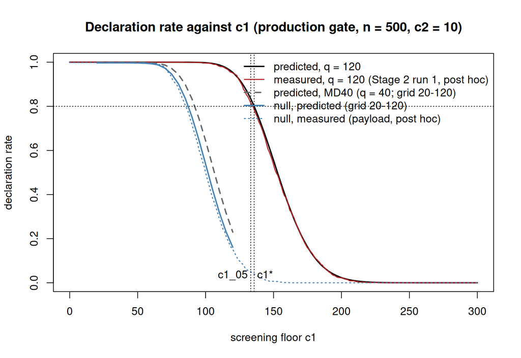

```r
.g40 <- .sw[.sw$n == 500 & .sw$consistency_method == "resample", ]; .g40 <- .g40[order(.g40$c1), ]
.g120 <- FC$grid$resample$table
.n0 <- .nsw[.nsw$consistency_method == "resample", ]; .n0 <- .n0[order(.n0$c1), ]
plot(NA, xlim = c(0, 300), ylim = c(0, 1), xlab = "screening floor c1",
     ylab = "declaration rate", main = sprintf("Declaration rate against c1 (production gate, n = 500, c2 = %g)", FC$grid_settings$c2))
lines(.g120$c1, .g120$det_rate, lwd = 2)
lines(S2$curve$c1, S2$curve$measured, col = "firebrick", lwd = 1.5)
lines(.g40$c1, .g40$det_rate, col = "grey40", lwd = 2, lty = 2)
lines(.n0$c1, .n0$det_rate, col = "steelblue", lwd = 2)
lines(S2$null_curve$c1, S2$null_curve$measured, col = "steelblue", lwd = 1.5, lty = 3)
abline(h = 0.80, lty = 3); abline(v = c(.c1_05, FC$c1_star), lty = 3)
text(.c1_05, 0.02, "c1_05", adj = c(1.1, 0)); text(FC$c1_star, 0.02, "c1*", adj = c(-0.2, 0))
legend("topright", bty = "n", lwd = c(2, 1.5, 2, 2, 1.5), lty = c(1, 1, 2, 1, 3),
       col = c("black", "firebrick", "grey40", "steelblue", "steelblue"),
       legend = c(sprintf("predicted, q = %d", FC$q), sprintf("measured, q = %d (Stage 2 run 1, post hoc)", FC$q),
                  "predicted, MD40 (q = 40; grid 20-120)", "null, predicted (grid 20-120)", "null, measured (payload, post hoc)"))
```

```r
.sb <- rbind(
  data.frame(q = 40, k_inter = .f(L0$k40, 4), min = .f(L0$se_diag$overall[["min"]], 4), median = .f(L0$se_diag$overall[["median"]], 4),
             max = .f(L0$se_diag$overall[["max"]], 4), `outside ±2%` = L0$se_diag$outside_2pct, check.names = FALSE),
  do.call(rbind, lapply(LR, function(r) data.frame(q = r$q, k_inter = .f(r$k_inter, 4), min = .f(r$se_diag$overall[["min"]], 4),
    median = .f(r$se_diag$overall[["median"]], 4), max = .f(r$se_diag$overall[["max"]], 4), `outside ±2%` = r$se_diag$outside_2pct, check.names = FALSE))))
knitr::kable(.sb, row.names = FALSE, caption = sprintf(
  "The se_g / se_direct ratio over the M = %s family members per rung (se_direct = sqrt(V_eff[g] / (n·Pg)) from fs_dgm_scale on each candidate), from the ladder .rds.", .fm(L0$family$M)))
```

The se_g / se_direct ratio over the M = 1,696 family members per rung (se_direct = sqrt(V_eff[g] / (n·Pg)) from fs_dgm_scale on each candidate), from the ladder .rds.

| q | k_inter | min | median | max | outside ±2% |
| --- | --- | --- | --- | --- | --- |
| 40 | -13.7448 | 0.9923 | 0.9987 | 1.0106 | 0 |
| 60 | -33.7448 | 0.9917 | 0.9974 | 1.0094 | 0 |
| 80 | -53.7448 | 0.9864 | 0.9944 | 1.0077 | 0 |
| 100 | -73.7448 | 0.9783 | 0.9887 | 1.0072 | 11 |
| 120 | -93.7448 | 0.9675 | 0.9803 | 1.0064 | 813 |
| 140 | -113.7448 | 0.9539 | 0.9695 | 1.0060 | 1363 |
| 160 | -133.7448 | 0.9385 | 0.9565 | 1.0060 | 1425 |

At the forecast rung the direct-`V_eff` sensitivity (the same family with `se_g` replaced by `se_direct`) moved the predicted power at `c1*` from 0.800 to 0.810 and PPV from 0.775 to 0.763; the constructor is unchanged — the decision is recorded as open in the handoff.

# 11 Limitations

**The size of the selected rule.** The prediction conditions on a fixed candidate family enumerated at population quantiles on the DGM’s super-population. Within every covariate signature the realized subgroup size matches its population value, but the search selects rules that are on average larger than the analytic selection weights predict — by +2.11 subjects at n = 500 under the alternative, +0.61 at n = 700, and +1.65 at the n = 500 null (corrected 13-confounder family, 2 × 10⁵ draws, seed 20260825). `E|Ĥ|`, PPV, sensitivity and the naive bias inherit this gap; the declaration rate, specificity, `E[β(Ĥ)]` and the null false-declaration rate do not. Five mechanisms were tested and eliminated: sample realization within signature; the confounder list; the prevalence scaling of `se_g`, measured within [0.992, 1.015] across 5,282 family members; statistics-keyed near-duplicate removal, at most 5% of the gap; and cut placement at replicate rather than population quantiles, under which a replicate-averaged family moves the prediction away from measurement, widening the gap to +3.03 / +1.99 / +2.55. The realized family also differs from the enumerated one in structure: at this DGM `wtkg` retains a fourth default cut in most n = 500 samples that the population enumeration collapses, `karnof` falls below four distinct values and is handled as categorical in about 40% of samples, 71% of the selection mass sits on affected candidates, and only about a quarter of replicates realize the population label set exactly — variation the fixed-family framework cannot represent. The gap is recorded as a limitation of the fixed-family prediction and is not explained.

**The true rule need not be a family member.** The enumeration cuts continuous covariates at a specified population quantile grid, so a true subgroup defined by thresholds off that grid is represented only by its nearest members. At this DGM, Q — defined by thresholds at age 34 and preanti 744.5 — is not a member of the enumerated family; the closest candidates have purity `PQg ≥ 0.95`, and at the breadth forecast rung 0.345 of the selection mass sits on them. Sensitivity and PPV of the selected rule are therefore bounded by the grid before any sampling enters, and “power” throughout this document is the probability of declaring some rule, whose composition the selection distribution reports.

# 12 Reading the comparison

```r
.r5 <- G$runs$n500_resample$pred; .s5 <- G$runs$n500_split$pred; .m5 <- G$measured[["500"]]
.r7 <- G$runs$n700_resample$pred; .s7 <- G$runs$n700_split$pred; .m7 <- G$measured[["700"]]
```

What agreement **does** establish: that a fixed population enumeration of the driver’s cut space, with the scale table’s means and SEs and either gate, reproduces the measured selection functionals – E|Ĥ| (70.8 / 70.8 against 72.3 at n = 500; 73.0 / 73.1 against 73.6 at n = 700), sensitivity, specificity, PPV, NPV, the oriented effect on the selected rule and the naive selection bias – to within the measured MC uncertainty or close to it. That is a statement about the *family*: the stylized M = 16 of the analytic document could not do this, and the difference between it and the enumeration is the family, not the gate or the scale.

What agreement **does not** establish: